# Missingness and SVM analysis in R

Michael McDonagh (2392623)

2026

## 0. Introduction

In this file we will investigate missingness in the data sets that were exported after the EDA, and fit a chosen Support Vector Machine model to the data with selected predictors.

SVMs offer many advantages over other classification methods - the main one being that they use the decision boundary with the maximum margin between classes. This can often help them perform better than other decision boundary based classifiers like logistic regression. They also don’t need this decision boundary to be linear. Furthermore SVMs generally perform well on high-dimensional data with what can be a relatively manageable amount of memory usage needed for predictions once fitted. We will use a radial basis function (RBF) kernel to allow the SVM to learn potential non-linear relationships between the predictors.

Packages to load in order to run the file:

```r
library(e1071)
library(caret)
library(mice)
library(pROC)
```

```r
library(ggplot2)
library(patchwork)
library(gplots)
```

As some files need to be imported from my folder in the repository (MichaelM), the working directory should be set to “~/GitHub/Sprint-1” or equivalent.

## 1. Data Pre-Processing and Missingness Analysis

Firstly we import the test and training data that was left after the EDA:

```r
train_data<-read.csv("../processed-data/football_train_data.csv")
test_data<-read.csv("../processed-data/football_test_data.csv")
```

Finding the number of rows:

```r
nrow(train_data)
```

```
## [1] 37824
```

```r
nrow(test_data)
```

```
## [1] 8740
```

Now we check which predictors have no missing variables:

```r
# Pulling out the predictor variables from the outcome
predictors<-setdiff(names(train_data), "FTR")

selected_predictors <- predictors[
    colSums(is.na(train_data[, predictors, drop = FALSE])) == 0
]

selected_predictors
```

```
## character(0)
```

This means that all predictors have at least one row with missing values, which is a problem. It seems odd for the simple match statistics to have missing values - let’s just check the extent of it:

```r
# Seeing which rows have missing values of Away Shots on Target
which(is.na(train_data$AST))
```

```
## [1] 8808
```

After personally inspecting the Excel file, this row seems to have N/A for all of the match statistics. Removing it and inspecting for missingness:

```r
train_data1<-train_data[-8808,]
sum(colSums(is.na(train_data1[, predictors, drop = FALSE])) == 0)
```

```
## [1] 10
```

Now 10 predictors have no missing values - slightly lower than expected of 12 match statistics. Looking at which were fine:

```r
selected_predictors1 <- predictors[
    colSums(is.na(train_data1[, predictors, drop = FALSE])) == 0
]
selected_predictors1
```

```
##  [1] "HS"  "AS"  "HST" "AST" "HC"  "AC"  "HY"  "AY"  "HR"  "AR"
```

AF and HF are the only two match statistics missing. Investigating:

```r
which(is.na(train_data$AF))
```

```
## [1]  8808 32940 32949
```

```r
which(is.na(train_data$HF))
```

```
## [1]  8808 32940 32949
```

So now for a NON-Betting Model we can use the training data without these 3 rows: (for now we aren’t going to do any imputation as it isn’t strictly necessary when we still have 37821 observations)

```r
train_data_NB<-train_data[-c(8808,32940,32949),]
selected_predictors_NB<- predictors[
    colSums(is.na(train_data_NB[, predictors, drop = FALSE])) == 0
]
```

Just checking again that this works:

```r
sum(colSums(is.na(train_data_NB[, predictors, drop = FALSE])) == 0)
```

```
## [1] 12
```

```r
selected_predictors_NB
```

```
##  [1] "HS"  "AS"  "HST" "AST" "HF"  "AF"  "HC"  "AC"  "HY"  "AY"  "HR"  "AR"
```

```r
nrow(train_data_NB)
```

```
## [1] 37821
```

Next we will further examine missingness in order to get a training dataset that we can use for a Betting Odds Model:

```r
# We've already checked for the (non-betting) match statistics
odds_var<-setdiff(predictors, selected_predictors_NB)

missingness <- data.frame(
  Variable = odds_var,
  Missing_N = sapply(train_data[odds_var], function(x) sum(is.na(x))),
  Missing_Percent = sapply(
    train_data[odds_var],
    function(x) mean(is.na(x)) * 100
  )
)

missingness <- missingness[
  order(-missingness$Missing_Percent),
]
```

Checking the table:

```r
missingness
```

```
##              Variable Missing_N Missing_Percent
## CLH               CLH     36650     96.89615059
## CLD               CLD     36650     96.89615059
## CLA               CLA     36650     96.89615059
## BMGMH           BMGMH     36197     95.69849831
## BMGMD           BMGMD     36197     95.69849831
## BMGMA           BMGMA     36197     95.69849831
## X1XBH           X1XBH     36196     95.69585448
## X1XBD           X1XBD     36196     95.69585448
## X1XBA           X1XBA     36196     95.69585448
## SOD               SOD     36171     95.62975888
## SOH               SOH     36170     95.62711506
## SOA               SOA     36170     95.62711506
## BFH               BFH     36168     95.62182741
## BFD               BFD     36168     95.62182741
## BFA               BFA     36168     95.62182741
## BFDH             BFDH     36168     95.62182741
## BFDD             BFDD     36168     95.62182741
## BFDA             BFDA     36168     95.62182741
## BVH               BVH     36168     95.62182741
## BVD               BVD     36168     95.62182741
## BVA               BVA     36168     95.62182741
## LBAH             LBAH     35804     94.65947547
## LBAHH           LBAHH     35803     94.65683164
## LBAHA           LBAHA     35803     94.65683164
## B365AH         B365AH     35366     93.50148054
## GBAHA           GBAHA     35325     93.39308376
## GBAH             GBAH     35325     93.39308376
## GBAHH           GBAHH     35313     93.36135787
## BFEAHH         BFEAHH     34827     92.07645939
## BFEAHA         BFEAHA     34827     92.07645939
## GB.2.5         GB.2.5     34750     91.87288494
## GB.2.5.1     GB.2.5.1     34750     91.87288494
## BFE.2.5       BFE.2.5     34631     91.55826988
## BFE.2.5.1   BFE.2.5.1     34631     91.55826988
## BFEH             BFEH     34608     91.49746193
## BFED             BFED     34608     91.49746193
## BFEA             BFEA     34608     91.49746193
## BSH               BSH     27890     73.73625212
## BSD               BSD     27890     73.73625212
```

[output cut: 23 more lines]

```
## LBH               LBH     11819     31.24735618
## LBD               LBD     11819     31.24735618
## LBA               LBA     11819     31.24735618
## IWH               IWH      4254     11.24682741
## IWD               IWD      4254     11.24682741
## IWA               IWA      4254     11.24682741
## WHH               WHH      2439      6.44828680
## WHD               WHD      2439      6.44828680
## WHA               WHA      2439      6.44828680
## BWH               BWH      2353      6.22091794
## BWD               BWD      2353      6.22091794
## BWA               BWA      2353      6.22091794
## B365H           B365H         9      0.02379442
## B365D           B365D         9      0.02379442
## B365A           B365A         9      0.02379442
```

Unfortunately it seems that a vast majority of the values for the betting odds are missing. However the Bet365 variables (for Home win, Draw, Away win) have only 0.024% missingness. Investigating where:

```r
which(is.na(train_data$B365A))
```

```
## [1]   449 21573 21586 34276 34318 34335 34364 35508 35817
```

```r
which(is.na(train_data$B365D))
```

```
## [1]   449 21573 21586 34276 34318 34335 34364 35508 35817
```

```r
which(is.na(train_data$B365H))
```

```
## [1]   449 21573 21586 34276 34318 34335 34364 35508 35817
```

So only 9 more rows with missing values (none overlapping with the match statistics). For the Betting Model we will use the training data without these rows as well as the previous 3 rows we found had match statistics missing:

```r
train_data_B<-train_data_NB[complete.cases(train_data_NB[, c("B365H", "B365D", "B365A")]),]
selected_predictors_B<-unique(c(selected_predictors_NB, "B365H", "B365D", "B365A"))
nrow(train_data_B)
```

```
## [1] 37812
```

Again for now we are fine to use this as training data without imputation, but we will do imputation later.

## 2. Fitting the Baseline SVM models

Now we can train an SVM for each training dataset. First the Non-Betting model:

```r
# First converting the result to a factor variable
train_data_NB$FTR<-factor(train_data_NB$FTR, levels=c("H", "D", "A"))

# Fitting with default values of the parameters
baseline_svm_model_NB<-svm(FTR~., data=train_data_NB[, c("FTR", selected_predictors_NB)],
               kernel="radial", cost=1, gamma=1/length(selected_predictors_NB), scale=TRUE)
```

and the Betting model:

```r
train_data_B$FTR<-factor(train_data_B$FTR, levels=c("H", "D", "A"))
baseline_svm_model_B<-svm(FTR~., data=train_data_B[, c("FTR", selected_predictors_B)],
                 kernel="radial", cost=1, gamma=1/length(selected_predictors_B), scale=TRUE)
```

For a preliminary check, we can look at metrics such as the confusion matrix, accuracy, precision ,recall, F1 score etc. on the training sets of each. First defining a function that can do this:

```r
calculate_metrics <- function(actual, predicted) {

  actual <- factor(actual, levels = c("H", "D", "A"))
  predicted <- factor(predicted, levels = c("H", "D", "A"))

  # Getting confusion matrix and other metrics using caret package
  cm <- confusionMatrix(
    data = predicted,
    reference = actual
  )

  tab <- cm$table

  # Calculating precision, recall and F1 score for each outcome using their formulas
  precision <- diag(tab) / rowSums(tab)
  recall <- diag(tab) / colSums(tab)

  f1 <- 2 * precision * recall / (precision + recall)

  # Gives macro (unweighted mean) of each metric
  overall <- data.frame(
    Accuracy = as.numeric(cm$overall["Accuracy"]),
    Kappa = as.numeric(cm$overall["Kappa"]),
    Macro_Precision = mean(precision, na.rm = TRUE),
    Macro_Recall = mean(recall, na.rm = TRUE),
    Macro_F1 = mean(f1, na.rm = TRUE)
  )

  # Metrics for each individual outcome
  by_class <- data.frame(
    Outcome = c("Home win", "Draw", "Away win"),
    Precision = as.numeric(precision),
    Recall = as.numeric(recall),
    F1 = as.numeric(f1)
  )

  list(
    confusion_matrix = tab,
    overall = overall,
    by_class = by_class
  )
}
```

and then making predictions using the training datasets:

```r
baseline_training_predictions_NB<-predict(baseline_svm_model_NB, newdata=train_data_NB[, selected_predictors_NB, drop=FALSE])
baseline_training_predictions_B<-predict(baseline_svm_model_B, newdata=train_data_B[, selected_predictors_B, drop=FALSE])
```

Now we can view the performance metrics of this preliminary check:

```r
baseline_training_metrics_NB<-calculate_metrics(actual=train_data_NB$FTR,
                                                predicted = baseline_training_predictions_NB)
baseline_training_metrics_B<-calculate_metrics(actual=train_data_B$FTR,
                                               predicted = baseline_training_predictions_B)
```

First let’s see the training performance of the Non-Betting model:

```r
baseline_training_metrics_NB$overall
```

```
##   Accuracy    Kappa Macro_Precision Macro_Recall  Macro_F1
## 1 0.567912 0.301862        0.556113    0.5121467 0.4753727
```

```r
baseline_training_metrics_NB$by_class
```

```
##    Outcome Precision     Recall        F1
## 1 Home win 0.5745169 0.84474718 0.6839059
## 2     Draw 0.5337586 0.09823875 0.1659367
## 3 Away win 0.5600634 0.59345422 0.5762756
```

```r
baseline_training_metrics_NB$confusion_matrix
```

```
##           Reference
## Prediction     H     D     A
##          H 13766  6102  4093
##          D   374  1004   503
##          A  2156  3114  6709
```

and now the Betting model:

```r
baseline_training_metrics_B$overall
```

```
##    Accuracy     Kappa Macro_Precision Macro_Recall  Macro_F1
## 1 0.5858987 0.3342658       0.5720354    0.5334027 0.5029222
```

```r
baseline_training_metrics_B$by_class
```

```
##    Outcome Precision    Recall        F1
## 1 Home win 0.5927428 0.8430807 0.6960884
## 2     Draw 0.5416154 0.1293070 0.2087712
## 3 Away win 0.5817481 0.6278205 0.6039069
```

```r
baseline_training_metrics_B$confusion_matrix
```

```
##           Reference
## Prediction     H     D     A
##          H 13738  5840  3599
##          D   511  1321   607
##          A  2046  3055  7095
```

Note for reference that Precision for a given class measures the proportion of predictions of that class the SVM made that were actually correct. Meanwhile Recall measures the proportion of datapoints with a class that the SVM made correct predictions for, and F1 (score) is a combined metric of Precision and Recall for each class.

‘Kappa’ is Cohen’s Kappa - an overall metric with formula
$$\kappa = \frac{p_o-p_e}{1-p_e}$$
where $p_o$ is the observed agreement - the proportion of datapoints for which the model predicted the same class that the data point is (i.e the accuracy in this case), and $p_e$ is the expected agreement by chance - the probability that the model would predict the same class that the data point is by chance (calculated by using the individual proportions of each class for the actual and predicted outcomes).

From the American National Institutes of Health, a suggestive scale to interpret this was proposed by Cohen: “Cohen suggested the Kappa result be interpreted as follows: values ≤ 0 as indicating no agreement and 0.01–0.20 as none to slight, 0.21–0.40 as fair, 0.41– 0.60 as moderate, 0.61–0.80 as substantial, and 0.81–1.00 as almost perfect agreement.” (Source: https://pmc.ncbi.nlm.nih.gov/articles/PMC3900052/, Author: Mary L McHugh, Date: 15/10/2012)

Although the specific boundaries of this scale are critiqued in the same article for being too lenient (in particular referring to use in healthcare), this gives a general sense of how the Kappa score’s value (between -1 and 1) relates to better models.

We have a slight idea now of how the SVMs are doing with this classification (the performance shown by the metrics might be a bit optimistic as the SVMs were trained on the same datasets that they are being assessed on), though we will have to dig deeper into this by performing Cross Validation before drawing any conclusions.

## 3. Finding the Strongest Models through K-fold Cross Validation, and CV Performance Comparison

Here we perform 5-Fold Cross Validation to get the best combination of parameter values for ‘cost’ and ‘gamma’. We loop through 3 values of each: for cost 0.5, 2, and 8; for gamma 0.01, 0.05 and 0.2 therefore 9 combinations. The loss function used is just the misclassification rate.

Unfortunately over 5 folds this leaves us with 45 SVMs to fit for both Betting and Non-Betting datasets (so 90 total), which takes a long time to run but is just about doable over a full day. If it was feasible, more parameter values would have been tried.

In order to avoid having to run this extremely computationally expensive operation each time the file was run through; the final, best performing SVM model for both cases was saved in an RDS file in my named folder for easy access. The code that was originally run is below, but turned into a comment(s).

```r
# Initializing with a given seed in order to be repeatable

#set.seed(123)
#svm_tuning_NB<-tune(svm, FTR~., data=train_data_NB[, c("FTR", selected_predictors_NB)],
 #                       kernel="radial", ranges=list(cost=c(0.5,2,8), gamma=c(0.01,0.05,0.2)),
  #                      tunecontrol=tune.control(cross=5))

#best_parameters_NB<-svm_tuning_NB$best.parameters
#best_svm_NB<-svm_tuning_NB$best.model

#saveRDS(list(
 # best_svm_NB=best_svm_NB,
  #best_parameters_NB=best_parameters_NB,
  #svm_tuning_NB=svm_tuning_NB
  #),
  #"../MichaelM/best_svm_model_NB.rds")
```

```r
# Repeating for the model with the B365 variables:

#set.seed(123)
#svm_tuning_B<-tune(svm, FTR~., data=train_data_B[, c("FTR", selected_predictors_B)],
 #                       kernel="radial", ranges=list(cost=c(0.5,2,8), gamma=c(0.01,0.05,0.2)),
  #                      tunecontrol=tune.control(cross=5))

#best_parameters_B<-svm_tuning_B$best.parameters
#best_svm_B<-svm_tuning_B$best.model

#saveRDS(list(
 # best_svm_B=best_svm_B,
  #best_parameters_B=best_parameters_B,
  #svm_tuning_B=svm_tuning_B
  #),
  #"../MichaelM/best_svm_model_B.rds")
```

Extracting the tuned SVMs from their locations:

```r
tuned_svm_NB<-readRDS("../MichaelM/best_svm_model_NB.rds")
tuned_svm_B<-readRDS("../MichaelM/best_svm_model_B.rds")

best_svm_NB<-tuned_svm_NB$best_svm_NB
best_svm_B<-tuned_svm_B$best_svm_B

best_parameters_NB<-tuned_svm_NB$best_parameters_NB
best_parameters_B<-tuned_svm_B$best_parameters_B
```

Checking the best parameter values:

```r
best_parameters_NB
```

```
##   cost gamma
## 2    2  0.01
```

```r
best_parameters_B
```

```
##   cost gamma
## 1  0.5  0.01
```

They both ended up using the same value of gamma (which was the smallest), but the best Betting SVM used a smaller value of cost than the best Non-Betting SVM.

We can also check their performance; i.e. the best performance across the 5-fold Cross Validation:

```r
tuned_svm_NB$svm_tuning_NB$best.performance
```

```
## [1] 0.4517335
```

```r
tuned_svm_B$svm_tuning_B$best.performance
```

```
## [1] 0.4398602
```

These give the CV Error, which is equal to 1 minus the Accuracy. Hence we can see that the Betting Model had a slightly higher Accuracy during the cross validation.

We would like to get further metrics for the best performing models from the cross validation, however getting these independently of the original CV process would have required us to have used Nested CV, which was simply too computationally expensive to run. Thus as a compromise we will generate Out-Of-Fold predictions using both models with their ‘best parameters’. This is not a representation of what was actually generated in the 5-fold CV, but will serve as a useful, additional experiment to compare the two.

First creating a function to generate the Out-Of-Fold predictions:

```r
generate_oof_predictions <- function(data, predictors, tuning_object,
                                     cost, gamma) {

  n <- nrow(data)
  folds <- tuning_object$train.ind

  # Storing one out-of-fold prediction for every observation
  oof_predictions <- rep(NA_character_, n)

  for (i in seq_along(folds)) {

    # Indices used to fit the model
    train_indices <- folds[[i]]

    # Indices held out from this fold
    test_indices <- setdiff(seq_len(n), train_indices)

    # Fitting SVM using the best parameters from the K fold CV
    fold_model <- svm(
      FTR ~ .,
      data = data[train_indices, c("FTR", predictors), drop = FALSE],
      kernel = "radial",
      cost = cost,
      gamma = gamma
    )

    # Predicting only the held-out observations
    oof_predictions[test_indices] <- as.character(
      predict(
        fold_model,
        newdata = data[test_indices, predictors, drop = FALSE]
      )
    )

    cat("Completed fold", i, "of", length(folds), "\n")
  }

  factor(oof_predictions, levels = c("H", "D", "A"))
}
```

Now generating OOF predictions for each model - like with the 5-fold CV, I saved it to an RDS file to prevent it from having to run each time the file was run (though it’s not quite as long). Consequently I’ve put the original code but as a comment(s).

```r
#set.seed(123)

#oof_predictions_B <- generate_oof_predictions(
#  data = train_data_B,
#  predictors = selected_predictors_B,
#  tuning_object = tuned_svm_B$svm_tuning_B,
#  cost = tuned_svm_B$best_parameters_B$cost,
#  gamma = tuned_svm_B$best_parameters_B$gamma
#)

#saveRDS(oof_predictions_B, "../MichaelM/oof_predictions_B.rds")
```

```r
#set.seed(123)

#oof_predictions_NB <- generate_oof_predictions(
#  data = train_data_NB,
#  predictors = selected_predictors_NB,
#  tuning_object = tuned_svm_NB$svm_tuning_NB,
#  cost = tuned_svm_NB$best_parameters_NB$cost,
#  gamma = tuned_svm_NB$best_parameters_NB$gamma
#)

#saveRDS(oof_predictions_NB, "../MichaelM/oof_predictions_NB.rds")
```

Extracting the OOF predictions for each model:

```r
oof_predictions_B<-readRDS("../MichaelM/oof_predictions_B.rds")
oof_predictions_NB<-readRDS("../MichaelM/oof_predictions_NB.rds")
```

and calculating the metrics:

```r
oof_metrics_B <- calculate_metrics(
  actual = train_data_B$FTR,
  predicted = oof_predictions_B
)

oof_metrics_NB <- calculate_metrics(
  actual = train_data_NB$FTR,
  predicted = oof_predictions_NB
)
```

Now comparing:

Overall statistics

```r
oof_metrics_B$overall
```

```
##    Accuracy     Kappa Macro_Precision Macro_Recall  Macro_F1
## 1 0.5601396 0.2914344       0.5204834    0.5050223 0.4585351
```

```r
oof_metrics_NB$overall
```

```
##    Accuracy     Kappa Macro_Precision Macro_Recall  Macro_F1
## 1 0.5482668 0.2691971        0.507202    0.4909436 0.4431671
```

Class-specific statistics

```r
oof_metrics_B$by_class
```

```
##    Outcome Precision     Recall        F1
## 1 Home win 0.5774636 0.82712488 0.6801060
## 2     Draw 0.4408533 0.06675803 0.1159568
## 3 Away win 0.5431335 0.62118397 0.5795426
```

```r
oof_metrics_NB$by_class
```

```
##    Outcome Precision     Recall        F1
## 1 Home win 0.5624974 0.83094011 0.6708613
## 2     Draw 0.4249084 0.05675147 0.1001295
## 3 Away win 0.5342001 0.58513932 0.5585106
```

Confusion matrices

```r
oof_metrics_B$confusion_matrix
```

```
##           Reference
## Prediction     H     D     A
##          H 13478  6066  3796
##          D   380   682   485
##          A  2437  3468  7020
```

```r
oof_metrics_NB$confusion_matrix
```

```
##           Reference
## Prediction     H     D     A
##          H 13541  6286  4246
##          D   341   580   444
##          A  2414  3354  6615
```

As we can see the reported OOF Accuracy is very similar to that of the original CV, which supports the use of these extra metrics as criteria together with the accuracy.

From before, the Betting model’s original CV accuracy is slightly higher than the Non-Betting model’s. The OOF predictions’ metrics are consistent with this - not only higher in accuracy, but also Macro Precision, Macro Recall, Macro F1 score and Cohen’s Kappa.

The class-specific statistics and the confusion matrices do reveal that the Betting model wasn’t entirely dominant in its OOF predictions - the Non-Betting model predicted more Home wins correctly, which lead to it having a higher Home win Recall. However, this could potentially be attributed to it just predicting Home wins more frequently over the dataset.

While the differences in the OOF prediction metrics, as well as the difference in actual CV accuracy, are small, in combination the evidence points towards the best Betting SVM as our choice of model. We will move forward with analyzing its performance on the test data, after a short detour on imputation.

## 4. Imputation Test

In this section we will perform imputation on the training data. We already have our chosen model, therefore this section will just be a separate experiment, that unfortunately couldn’t be utilised. The reason for this is that the missingness was just too high across the board to justify, and it would have also required imputation on the test set for the final evaluation if it was selected.

Recalling the table for missingness:

```r
missingness
```

```
##              Variable Missing_N Missing_Percent
## CLH               CLH     36650     96.89615059
## CLD               CLD     36650     96.89615059
## CLA               CLA     36650     96.89615059
## BMGMH           BMGMH     36197     95.69849831
## BMGMD           BMGMD     36197     95.69849831
## BMGMA           BMGMA     36197     95.69849831
## X1XBH           X1XBH     36196     95.69585448
## X1XBD           X1XBD     36196     95.69585448
## X1XBA           X1XBA     36196     95.69585448
## SOD               SOD     36171     95.62975888
## SOH               SOH     36170     95.62711506
## SOA               SOA     36170     95.62711506
## BFH               BFH     36168     95.62182741
## BFD               BFD     36168     95.62182741
## BFA               BFA     36168     95.62182741
## BFDH             BFDH     36168     95.62182741
## BFDD             BFDD     36168     95.62182741
## BFDA             BFDA     36168     95.62182741
## BVH               BVH     36168     95.62182741
## BVD               BVD     36168     95.62182741
## BVA               BVA     36168     95.62182741
## LBAH             LBAH     35804     94.65947547
## LBAHH           LBAHH     35803     94.65683164
## LBAHA           LBAHA     35803     94.65683164
## B365AH         B365AH     35366     93.50148054
## GBAHA           GBAHA     35325     93.39308376
## GBAH             GBAH     35325     93.39308376
## GBAHH           GBAHH     35313     93.36135787
## BFEAHH         BFEAHH     34827     92.07645939
## BFEAHA         BFEAHA     34827     92.07645939
## GB.2.5         GB.2.5     34750     91.87288494
## GB.2.5.1     GB.2.5.1     34750     91.87288494
## BFE.2.5       BFE.2.5     34631     91.55826988
## BFE.2.5.1   BFE.2.5.1     34631     91.55826988
## BFEH             BFEH     34608     91.49746193
## BFED             BFED     34608     91.49746193
## BFEA             BFEA     34608     91.49746193
## BSH               BSH     27890     73.73625212
## BSD               BSD     27890     73.73625212
```

[output cut: 23 more lines]

```
## LBH               LBH     11819     31.24735618
## LBD               LBD     11819     31.24735618
## LBA               LBA     11819     31.24735618
## IWH               IWH      4254     11.24682741
## IWD               IWD      4254     11.24682741
## IWA               IWA      4254     11.24682741
## WHH               WHH      2439      6.44828680
## WHD               WHD      2439      6.44828680
## WHA               WHA      2439      6.44828680
## BWH               BWH      2353      6.22091794
## BWD               BWD      2353      6.22091794
## BWA               BWA      2353      6.22091794
## B365H           B365H         9      0.02379442
## B365D           B365D         9      0.02379442
## B365A           B365A         9      0.02379442
```

We will choose to do imputation on a model including the 3 betting sites with less than 12% of their odds missing - Betway, William Hill and Interwetten. We will also impute the extra 12 (assuming no overlap) total missing cases we already had, in order to bring the number of observations back to level with the original training data.

```r
impute_vars <- c(
  "BWA", "BWD", "BWH",
  "WHA", "WHD", "WHH",
  "IWH", "IWD", "IWA"
)

selected_predictors_imputed <- unique(c(selected_predictors_B, impute_vars))

train_imp <- train_data[, c("FTR", selected_predictors_imputed), drop = FALSE]
```

Using `mice` package for multiple imputation:

```r
ini <- mice(
  train_imp,
  maxit = 0,
  printFlag = FALSE
)
meth <- ini$method
pred <- ini$predictorMatrix

meth["FTR"] <- ""

pred[, "FTR"] <- 0

for (v in selected_predictors_imputed) {
  if (anyNA(train_imp[[v]])) {
    meth[v] <- "pmm"
  } else {
    meth[v] <- ""
  }
}

imp <- mice(
  train_imp,
  method = meth,
  predictorMatrix = pred,
  m = 5,
  maxit = 5,
  seed = 123,
  printFlag = FALSE
)

train_imp_filled1 <- complete(imp, 1)
train_imp_filled2 <- complete(imp, 2)
train_imp_filled3 <- complete(imp, 3)
train_imp_filled4 <- complete(imp, 4)
train_imp_filled5 <- complete(imp, 5)
```

Now fitting SVMs to their respective training data:

```r
# Converting results to factor variables
train_imp_filled1$FTR <- factor(train_imp_filled1$FTR, levels = c("H", "D", "A"))
train_imp_filled2$FTR <- factor(train_imp_filled2$FTR, levels = c("H", "D", "A"))
train_imp_filled3$FTR <- factor(train_imp_filled3$FTR, levels = c("H", "D", "A"))
train_imp_filled4$FTR <- factor(train_imp_filled4$FTR, levels = c("H", "D", "A"))
train_imp_filled5$FTR <- factor(train_imp_filled5$FTR, levels = c("H", "D", "A"))

imputed_svm1 <- svm(FTR ~ ., data = train_imp_filled1[, c("FTR", selected_predictors_imputed), drop = FALSE], kernel = "radial", cost = 1, gamma = 1 / length(selected_predictors_imputed), scale = TRUE)
imputed_svm2 <- svm(FTR ~ ., data = train_imp_filled2[, c("FTR", selected_predictors_imputed), drop = FALSE], kernel = "radial", cost = 1, gamma = 1 / length(selected_predictors_imputed), scale = TRUE)
imputed_svm3 <- svm(FTR ~ ., data = train_imp_filled3[, c("FTR", selected_predictors_imputed), drop = FALSE], kernel = "radial", cost = 1, gamma = 1 / length(selected_predictors_imputed), scale = TRUE)
imputed_svm4 <- svm(FTR ~ ., data = train_imp_filled4[, c("FTR", selected_predictors_imputed), drop = FALSE], kernel = "radial", cost = 1, gamma = 1 / length(selected_predictors_imputed), scale = TRUE)
imputed_svm5 <- svm(FTR ~ ., data = train_imp_filled5[, c("FTR", selected_predictors_imputed), drop = FALSE], kernel = "radial", cost = 1, gamma = 1 / length(selected_predictors_imputed), scale = TRUE)
```

and making predictions using their respective training data (for the same reason as the baseline models, their performances may be slightly optimistic due to this):

```r
imputed_svm_predictions1 <- predict(imputed_svm1, newdata = train_imp_filled1)
imputed_svm_predictions2 <- predict(imputed_svm2, newdata = train_imp_filled2)
imputed_svm_predictions3 <- predict(imputed_svm3, newdata = train_imp_filled3)
imputed_svm_predictions4 <- predict(imputed_svm4, newdata = train_imp_filled4)
imputed_svm_predictions5 <- predict(imputed_svm5, newdata = train_imp_filled5)
```

Now we can get an idea of how the metrics vary across the five imputations:

```r
imputed_metrics1 <- calculate_metrics(actual = train_imp_filled1$FTR, predicted = imputed_svm_predictions1)
imputed_metrics2 <- calculate_metrics(actual = train_imp_filled2$FTR, predicted = imputed_svm_predictions2)
imputed_metrics3 <- calculate_metrics(actual = train_imp_filled3$FTR, predicted = imputed_svm_predictions3)
imputed_metrics4 <- calculate_metrics(actual = train_imp_filled4$FTR, predicted = imputed_svm_predictions4)
imputed_metrics5 <- calculate_metrics(actual = train_imp_filled5$FTR, predicted = imputed_svm_predictions5)
```

putting into a table:

```r
imputation_comparison <- data.frame(
  Imputation = paste("Imputation", 1:5),
  Accuracy = c(imputed_metrics1$overall$Accuracy,imputed_metrics2$overall$Accuracy,imputed_metrics3$overall$Accuracy,
               imputed_metrics4$overall$Accuracy,imputed_metrics5$overall$Accuracy),
  Kappa = c(imputed_metrics1$overall$Kappa, imputed_metrics2$overall$Kappa, imputed_metrics3$overall$Kappa,
            imputed_metrics4$overall$Kappa, imputed_metrics5$overall$Kappa),
  Macro_Precision = c(imputed_metrics1$overall$Macro_Precision, imputed_metrics2$overall$Macro_Precision,
                      imputed_metrics3$overall$Macro_Precision, imputed_metrics4$overall$Macro_Precision,
                      imputed_metrics5$overall$Macro_Precision),
  Macro_Recall = c(imputed_metrics1$overall$Macro_Recall, imputed_metrics2$overall$Macro_Recall,
                   imputed_metrics3$overall$Macro_Recall, imputed_metrics4$overall$Macro_Recall,
                   imputed_metrics5$overall$Macro_Recall),
  Macro_F1 = c(imputed_metrics1$overall$Macro_F1, imputed_metrics2$overall$Macro_F1,
               imputed_metrics3$overall$Macro_F1, imputed_metrics4$overall$Macro_F1,
               imputed_metrics5$overall$Macro_F1)
)

imputation_comparison
```

```
##     Imputation  Accuracy     Kappa Macro_Precision Macro_Recall  Macro_F1
## 1 Imputation 1 0.5808217 0.3262909       0.5609999    0.5281360 0.4954207
## 2 Imputation 2 0.5802136 0.3251118       0.5597511    0.5272911 0.4944684
## 3 Imputation 3 0.5807424 0.3259795       0.5613173    0.5278100 0.4951943
## 4 Imputation 4 0.5814562 0.3271218       0.5640956    0.5287398 0.4963158
## 5 Imputation 5 0.5808481 0.3262230       0.5608691    0.5280237 0.4953014
```

From this we can see that there is very little variance between the metrics gotten from each imputation. We can formalize this:

```r
imputation_summary <- data.frame(
  Metric = c("Accuracy", "Kappa", "Macro Precision",
             "Macro Recall", "Macro F1"),
  Mean = sapply(imputation_comparison[, -1], mean, na.rm = TRUE),
  SD = sapply(imputation_comparison[, -1], sd, na.rm = TRUE)
)

imputation_summary
```

```
##                          Metric      Mean           SD
## Accuracy               Accuracy 0.5808164 0.0004413682
## Kappa                     Kappa 0.3261454 0.0007204910
## Macro_Precision Macro Precision 0.5614066 0.0016150379
## Macro_Recall       Macro Recall 0.5280001 0.0005256039
## Macro_F1               Macro F1 0.4953401 0.0006597659
```

Each metric has an extremely low standard deviation across imputations. This indicates that the metrics were consistent through each imputation for the training data.

Furthermore the metrics were higher across the board than the Out-Of-Fold ones obtained by the best SVMs during cross validation. However as stated previously, this was expected since these metrics were calculated using predictions of the same datasets that the imputed models were trained on. In fact, the baseline models actually also performed better on their own training data. Therefore we cannot use this as evidence of better performance without doing Cross Validation on the imputed models.

Comparing the training performances of the baseline models and the imputed models, it suggests that adding betting odds as a predictor improves predictive performance, but does not keep stacking with more and more sites, i.e. there isn’t any extra predictive power to be gleaned from multiple different sites in this experiment. Again though as this is only based on training performance and the betting odds can potentially interact in different ways with the match statistics and each other, no definitive conclusions can be made.

Although the imputed datasets were not in consideration for building our final model, the patterns shown by these results are similar to what has been seen before. Hence this acts as useful information about how an SVM may perform if an imputation was required.

## 5. Evaluating the best Betting SVM on the test data

Now we can move onto evaluating the performance of our chosen ‘best’ SVM from Section 3 on the test data. Firstly there is something we must have in order to later plot the ROC curves - the prediction probabilities. Luckily as we already have the best parameters, we can just refit the same model, but retaining the probability estimates this time.

```r
best_svm_B_prob <- svm(FTR ~ ., data = train_data_B[, c("FTR", selected_predictors_B), drop = FALSE],
                       kernel = "radial", cost = best_parameters_B$cost, gamma = best_parameters_B$gamma,
                       scale = TRUE, probability = TRUE)
```

We will use this throughout the rest of the section. Now let’s just check that there are no missing values of the model’s selected predictors in the test data:

```r
sum(colSums(is.na(test_data[, selected_predictors_B, drop = FALSE])) == 0)
```

```
## [1] 15
```

So there are no missing values for all 15 selected predictors, and we can move onto predicting the results using `best_svm_B_prob`:

```r
test_predictions<-predict(best_svm_B_prob, newdata=test_data[, selected_predictors_B, drop=FALSE], probability=TRUE)
```

then getting its performance metrics:

```r
test_metrics<-calculate_metrics(actual=test_data$FTR, predicted = test_predictions)
```

which are sorted by:

Overall

```r
test_metrics$overall
```

```
##   Accuracy     Kappa Macro_Precision Macro_Recall  Macro_F1
## 1 0.601373 0.3471211       0.5274133    0.5307982 0.4884505
```

Class-specific statistics

```r
test_metrics$by_class
```

```
##    Outcome Precision     Recall        F1
## 1 Home win 0.6323248 0.83048290 0.7179822
## 2     Draw 0.3706468 0.06901343 0.1163608
## 3 Away win 0.5792683 0.69289827 0.6310086
```

Confusion matrix

```r
test_metrics$confusion_matrix
```

```
##           Reference
## Prediction    H    D    A
##          H 3302 1236  684
##          D  137  149  116
##          A  537  774 1805
```

These metrics reveal the overall classification performance of the best model. Clearly the SVM struggled a lot with identifying draws, though its accuracy for away and especially home wins was relatively good. This is a consistent pattern with the baseline models’ performance on the training data and this particular SVM’s OOF performance.

Earlier analysis of the data had revealed that the lower leagues had a smaller proportion of home wins and a higher proportion of draws in comparison with the Premier League. Thus it is possible that this fact could have contributed to the increase in overall accuracy, along with the other metrics, though it’s not proven. This is useful to consider when thinking about if the data from the lower leagues lends itself to training models for use on the Premier League.

As another assessment of the model’s classification performance, we can plot ROC curves for each of the outcomes:

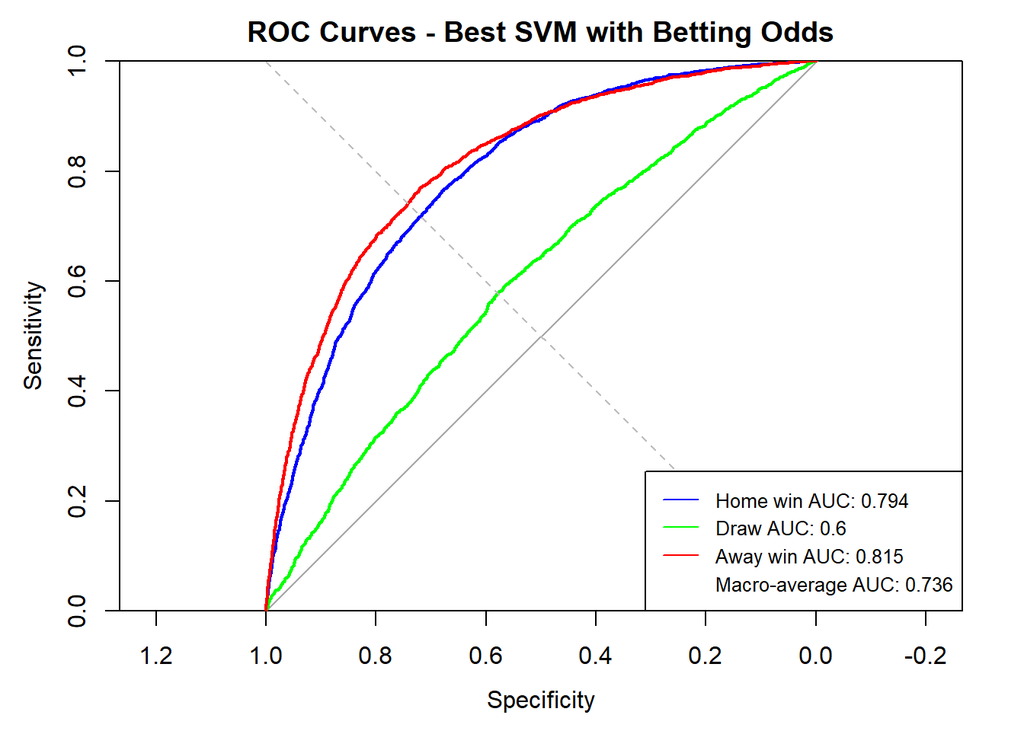

```r
prob_B <- attr(test_predictions, "probabilities")
actual <- factor(test_data$FTR, levels = c("H", "D", "A"))
prob_B <- prob_B[, levels(actual), drop = FALSE]

roc_H <- roc(actual == "H", prob_B[, "H"], quiet = TRUE)
roc_D <- roc(actual == "D", prob_B[, "D"], quiet = TRUE)
roc_A <- roc(actual == "A", prob_B[, "A"], quiet = TRUE)
macro_auc<-mean(c(auc(roc_H), auc(roc_D), auc(roc_A)))

plot(roc_H, col = "blue",
     xlim = c(1.0, 0.0),
     ylim = c(0.0, 1.0),
     xaxs = "i",
     yaxs = "i",
     main = "ROC Curves - Best SVM with Betting Odds")
plot(roc_D, col = "green", add = TRUE)
plot(roc_A, col = "red", add = TRUE)

abline(a = 0, b = 1, lty = 2, col = "grey")

legend(
  "bottomright",
  legend = c(
    paste("Home win AUC:", round(auc(roc_H), 3)),
    paste("Draw AUC:", round(auc(roc_D), 3)),
    paste("Away win AUC:", round(auc(roc_A), 3)),
    paste("Macro-average AUC:", round(macro_auc, 3))
  ),
  col = c("blue", "green", "red", "white"),
  lty = 1,
  cex = 0.8
)
```

Here the Macro-average AUC is a combined metric of each of the 3 calculated AUCs, just by taking the (unweighted) mean. Another, different, overall measurement that serves the same purpose is the Multi-class AUC:

```r
multiclass_auc <- pROC::multiclass.roc(response = actual, predictor = prob_B)
print(multiclass_auc)
```

```
##
## Call:
## multiclass.roc.default(response = actual, predictor = prob_B)
##
## Data: multivariate predictor prob_B with 3 levels of actual: H, D, A.
## Multi-class area under the curve: 0.7252
```

Either can be used but they are calculated differently. The Macro-average AUC gives each outcome the same weighting and averages each of their one-vs-rest AUCs. Meanwhile the Multi-class AUC uses the pairwise AUCs (not on the graph) for each combination of outcomes and averages between them.

From the ROC curves, we can see that while obviously the Draw outcome’s ROC curve was dominated by the other two, and it had the lowest AUC, the highest AUC was actually for Away wins. This differs from the hierarchy established by the class-specific Recall, Precision and F1 scores, where Home win was king. This suggests that although the SVM had more success classifying Home wins at its own probability decision threshold, the prediction probabilities it calculated were overall better - when going over all thresholds - at distinguishing Away wins from the other outcomes.

An important metric we can take in order to compare the SVM against other classification methods is the log loss/cross entropy. This is also calculated using the prediction probabilities:

```r
# This low value of epsilon is just to prevent any attempts at calculating log(0)
epsilon <- 1e-15
actual_probabilities <- prob_B[cbind(seq_along(actual), match(as.character(actual), colnames(prob_B)))]
log_loss_B <- -mean(log(pmax(actual_probabilities, epsilon)))
log_loss_B
```

```
## [1] 0.8823976
```

The closer the value is to 0 the better; though it is of most use comparatively, so we will keep it in mind for after we’ve fitted the other types of models.

We would like to further investigate the importance of the selected predictors. Before we begin, we will first create a heatmap to see the relationships they have with each other:

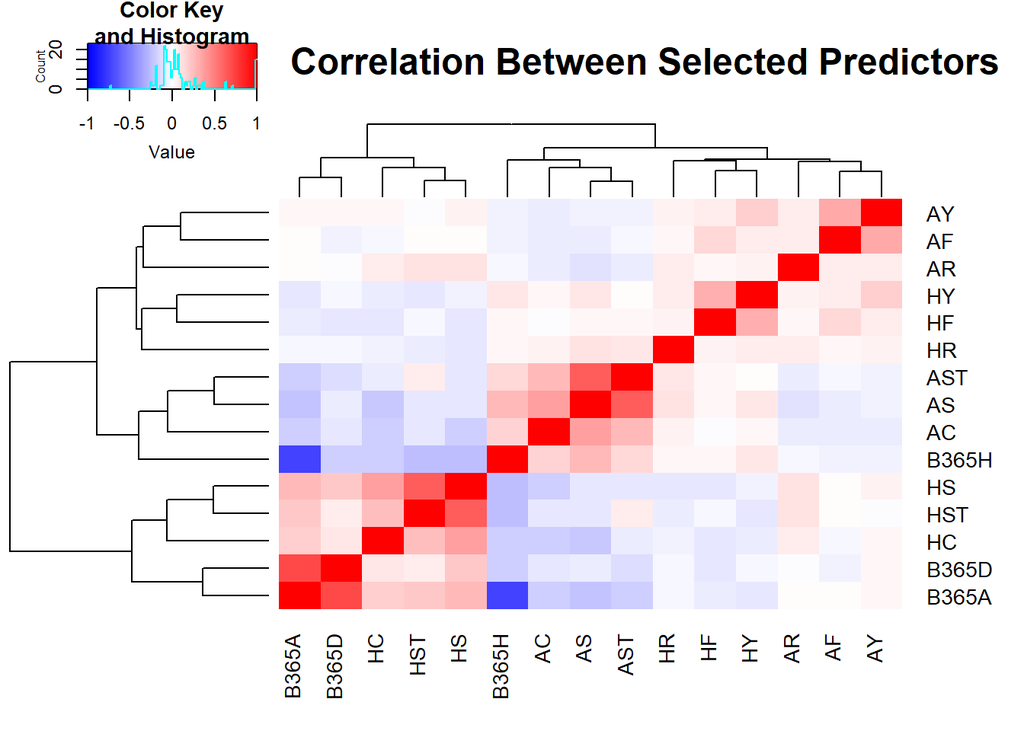

```r
predictor_correlations <- cor(train_data_B[, selected_predictors_B, drop=FALSE], use = "pairwise.complete.obs")

heatmap_colours <- colorRampPalette(c("blue", "white", "red"))(100)

heatmap.2(
  predictor_correlations,
  symm = TRUE,
  trace = "none",
  col = heatmap_colours,
  breaks = seq(-1, 1, length.out = 101),
  key = TRUE,
  main = "           Correlation Between Selected Predictors"
)
```

Next let’s focus in on the importance of each predictor. We can measure importance by checking how much the accuracy of the SVM’s predictions changes when randomly shuffling the values for each of the variables at a time (with a set seed). The more the accuracy decreases after shuffling, the more important the predictor.

For this test, we are only shuffling each variable once to avoid lengthy computation, so it should be kept in mind that the seed used for randomisation may have a small influence on the final score (this effect should hopefully be minimal over such a large data set).

Calculating the importance scores for each predictor:

```r
baseline_accuracy<-mean(test_predictions==actual)
# 'actual' is the same as for the ROC curve - the Full Time Results of the test data
set.seed(123)

importance_scores <- numeric(length(selected_predictors_B))
names(importance_scores) <- selected_predictors_B

for (variable in selected_predictors_B) {
  shuffled_test <- test_data[, selected_predictors_B, drop=FALSE]

  # Shuffling the values of the variable
  shuffled_test[[variable]] <- sample(shuffled_test[[variable]])

  # Making predictions with the shuffled variables in the data and calculating the accuracy
  shuffled_predictions <- predict(best_svm_B_prob, newdata = shuffled_test)
  shuffled_accuracy <- mean(shuffled_predictions == actual)

  # Calculating the change in accuracy after shuffling - the importance score of each variable
  importance_scores[variable] <- baseline_accuracy - shuffled_accuracy
}
```

Now we can plot a bar chart of feature importance to the best performing SVM:

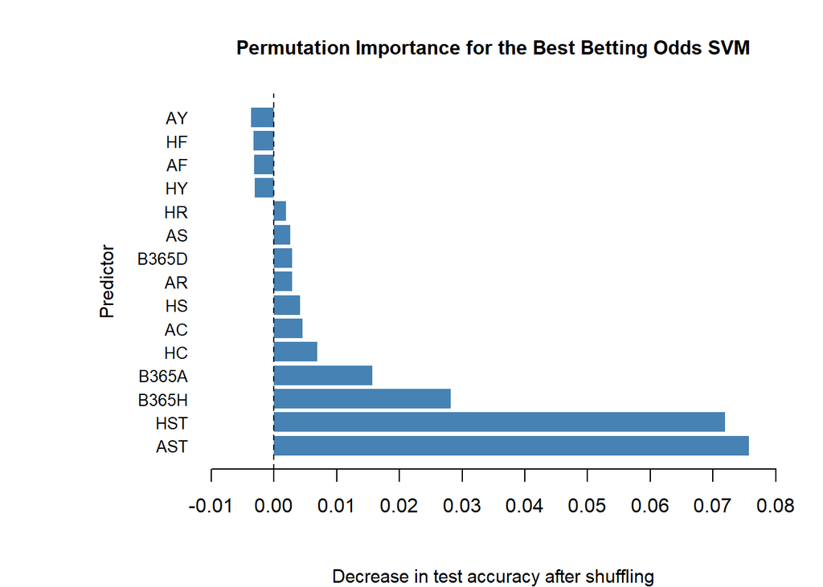

```r
# Putting the scores in order
importance_scores <- sort(importance_scores, decreasing = TRUE)

par(mar = c(5,9,4,2), mgp = c(4,1,0))

barplot(importance_scores, horiz = TRUE, las = 1, border = NA, col = "steelblue",
        main = "Permutation Importance for the Best Betting Odds SVM",
        xlab = "Decrease in test accuracy after shuffling",
        ylab = "Predictor",
        xlim = c(-0.01, 0.08),
        xaxt = "n", cex.names = 0.85, cex.axis = 0.85, cex.lab = 0.95, cex.main = 1)

axis(side = 1, at = seq(-0.01, 0.08, by = 0.01), labels = sprintf("%.2f", seq(-0.01, 0.08, by = 0.01)))
abline(v = 0, lty = 2)
```

From this we can see that Home and Away Shots on Target were found to have the biggest impact on the accuracy when shuffled - about a 7-7.5% decrease. This was followed by the Bet365 Home and Away win odds, though curiously in the opposite order. On the opposite end, the number of fouls and yellow cards of each team being shuffled actually increased the test accuracy; suggesting these had little value for prediction individually.

Zoning in on the most important predictors (AST, HST, B365H and B365A), we want to see how the predicted and actual outcomes are spread out across them. It makes sense to first do a comparison between AST and HST, which we will show using scatter plots:

```r
# Creating the tables of values of HST and AST with the actual and predicted outcomes
ST_actual <- data.frame(HST = test_data$HST, AST = test_data$AST,
                        Result = factor(test_data$FTR, levels = c("H", "D", "A")),
                        Type = "Actual Result")
ST_predicted <- data.frame(HST = test_data$HST, AST = test_data$AST,
                           Result = factor(test_predictions, levels = c("H", "D", "A")),
                           Type = "SVM prediction")

ST_compare <- rbind(ST_actual, ST_predicted)
```

and now putting the scatter plots side by side:

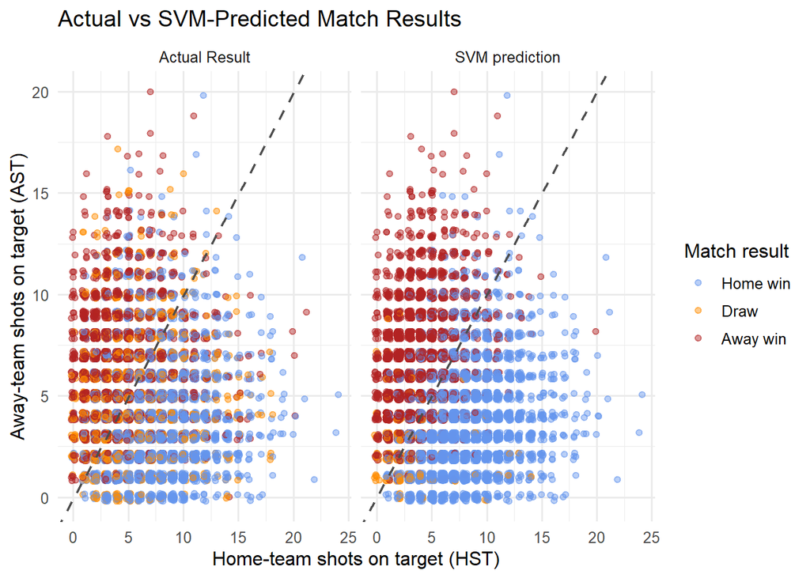

```r
ggplot(ST_compare, aes(x = HST, y = AST, colour = Result)) +
  geom_jitter(width = 0.2, height = 0.2, alpha = 0.45, size = 1.5) +
  facet_wrap(~Type) +
  scale_colour_manual(
    values = c("H" = "cornflowerblue", "D" = "darkorange", "A" = "firebrick"),
    labels = c("H" = "Home win", "D" = "Draw", "A" = "Away win")
  ) +
  geom_abline(
  slope = 1,
  intercept = 0,
  linetype = "dashed",
  colour = "grey30",
  linewidth = 0.8
  ) +
  labs(
    title = "Actual vs SVM-Predicted Match Results",
    x = "Home-team shots on target (HST)",
    y = "Away-team shots on target (AST)",
    colour = "Match result"
  ) +
  theme_minimal(base_size = 12)
```

These are split with a diagonal line where the number of home/away shots on target are equal, and being above/below the line corresponds to more away/home shots on target, respectively. From this we can see that the SVM predicted quite rigidly whichever team had more shots on target. That is not to say the SVM went solely by this principle, as there are some noticeable exceptions seen in the scatter graph - however, while the actual results have a similar trend, it is more mixed, particularly around the separating line.

We will now plot this same comparison between the Bet365 Home and Away odds. First creating the tables of values of B365A/H with the actual and predicted outcomes:

```r
odds_actual <- data.frame(B365H = test_data$B365H, B365A = test_data$B365A,
                          Result = factor(test_data$FTR, levels = c("H", "D", "A")),
                          Type = "Actual result")
odds_predicted <- data.frame(B365H = test_data$B365H, B365A = test_data$B365A,
                             Result = factor(test_predictions, levels = c("H", "D", "A")),
                             Type = "SVM prediction")
```

For the plotting, instead of the given values of the betting odds we will use 1/ them - which are roughly (NOT exactly) the implied probabilities of the site. This just makes the visual comparison clearer.

```r
odds_actual$HomeProb <- 1 / odds_actual$B365H
odds_actual$AwayProb <- 1 / odds_actual$B365A
odds_predicted$HomeProb <- 1 / odds_predicted$B365H
odds_predicted$AwayProb <- 1 / odds_predicted$B365A

odds_compare <- rbind(odds_actual, odds_predicted)
```

Now showing the graphs side by side:

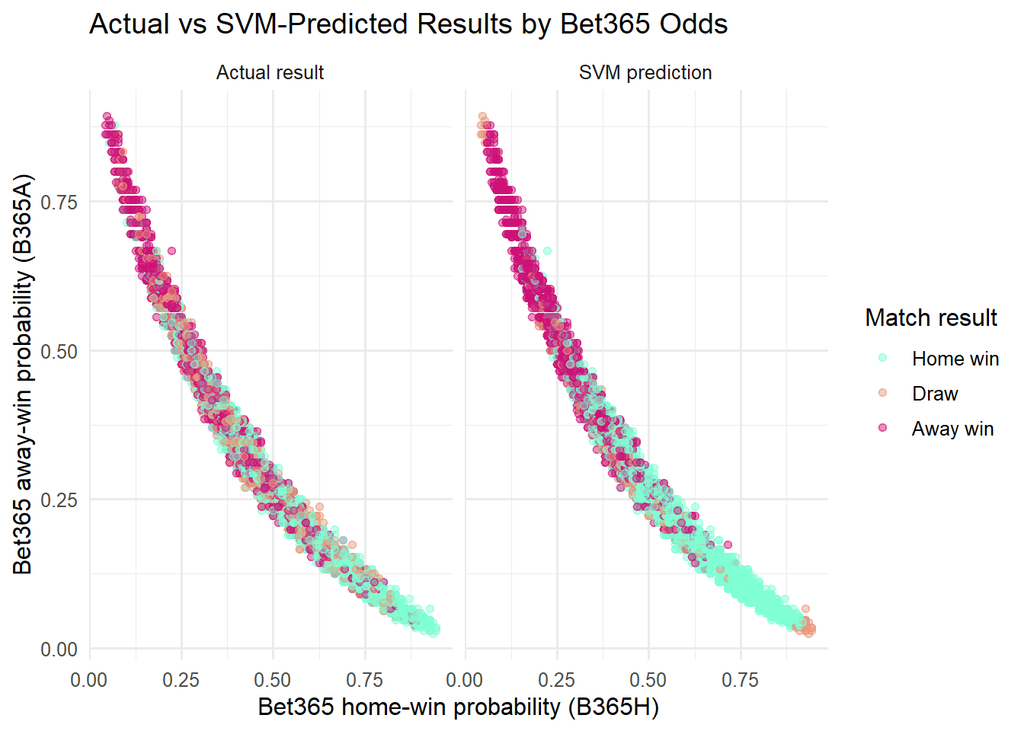

```r
ggplot(odds_compare, aes(x = HomeProb, y = AwayProb, colour = Result)) +
  geom_point(alpha = 0.45, size = 1.5) +
  facet_wrap(~Type) +
  scale_colour_manual(
    values = c("H" = "aquamarine", "D" = "darksalmon", "A" = "deeppink3"),
    labels = c("H" = "Home win", "D" = "Draw", "A" = "Away win")
  ) +
  labs(
    title = "Actual vs SVM-Predicted Results by Bet365 Odds",
    x = "Bet365 home-win probability (B365H)",
    y = "Bet365 away-win probability (B365A)",
    colour = "Match result"
  ) +
  theme_minimal(base_size = 12)
```

Like with the Shots on Target comparison, the SVM seemed to have a stricter cutoff; usually predicting either outcome if it had an implied probability of above 0.5, though for these predictors it isn’t as clear cut. This matches with the result of the calculated importance scores, which were lower for the odds than for the Shots on Target.

Finally we will investigate how much of an effect the betting odds for a draw can have in helping the SVM predict it, as it was consistently the result it had the most trouble with. We will do a boxplot comparing B365D odds before kickoff between matches that actually finished in a draw and matches that didn’t, to see if there is a noticeable difference in distribution. Firstly converting the outcomes to 2 results - whether its a draw or not:

```r
draw_data <- data.frame(
  B365D = test_data$B365D,
  Outcome = factor(
    ifelse(test_data$FTR == "D", "Draw", "Not a draw"),
    levels = c("Not a draw", "Draw")
  )
)
```

then making the boxplots:

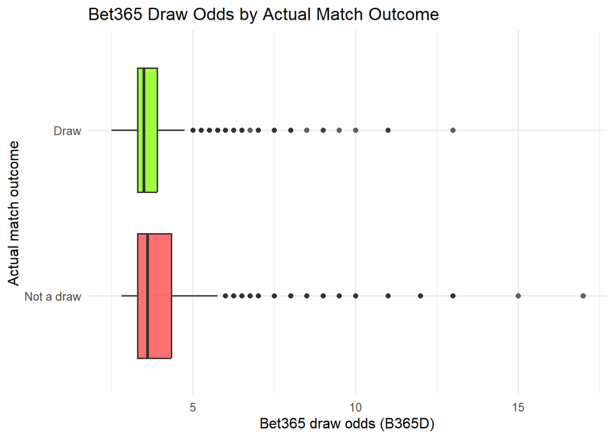

```r
ggplot(draw_data, aes(x = Outcome, y = B365D, fill = Outcome)) +
  geom_boxplot(alpha = 0.75, na.rm = TRUE) +
  scale_fill_manual(
    values = c("Not a draw" = "brown1", "Draw" = "chartreuse")
  ) +
  labs(
    title = "Bet365 Draw Odds by Actual Match Outcome",
    x = "Actual match outcome",
    y = "Bet365 draw odds (B365D)"
  ) +
  coord_flip() +
  theme_minimal(base_size = 12) +
  theme(legend.position = "none")
```

These boxplots looking broadly similar is consistent with the SVM’s struggles to classify a draw. It had been hoped that the Draw odds would have provided helpful information, yet we can see that the Bet365 Draw Odds alone do not largely differ between matches that were a draw and those that weren’t. This doesn’t give the full picture, as they could give stronger support in combination with other features - but as shown before, the match statistics by themselves also had a very low prediction accuracy on the training data for draws, so the improvement being limited is not surprising.

## 6. Conclusions

For our chosen ‘best’ SVM model, we got the following test metrics:

```r
test_metrics$overall
```

```
##   Accuracy     Kappa Macro_Precision Macro_Recall  Macro_F1
## 1 0.601373 0.3471211       0.5274133    0.5307982 0.4884505
```

including a test set accuracy of 60.14%. We also had a Macro-average AUC of 0.7363, a Multi-class AUC of 0.7252, and a log loss of 0.8824.

We also found that Draws were by far the hardest outcome for an SVM to classify, even with the additional information gained from Bet365’s opening odds.

Crucially, we showed that the performance of an SVM trained with lower league data on the Premier League could be at least a similar strength to its performance on its own training and validation data. This can act as evidence to support the use of lower league data in training models to be used on the Premier League. We should mention again that the data used includes full time match statistics, so this doesn’t necessarily translate to predictive models.